# Estimación del gasto turístico en Honduras mediante Modelos Multinivel Bayesianos

Author

Eduardo Canales, Asael Matamoros

Published

November 25, 2023

## Abstract

Tourism is one of the main economic activities of any developing country. One of the crucial aspects when carrying out studies of tourism indicators is the estimation of average expenditure per stay. To date, the methods used for this estimation have yet to incorporate multilevel hierarchies, leading to a failure to consider the asymmetry in the data distribution adequately. In this study, we propose an estimate of tourism expenditure disaggregated by areas visited by tourists using a multilevel `log-normal`model with hierarchical priors. The results indicate that our model is superior to the global models proposed in the literature.

## Introducción

El turismo es una actividad económica que en las últimas décadas se ha desarrollado de manera acelerada a nivel mundial. Según la OMT (2018) “es un sector fundamental de generación de ingresos en las economías emergentes y en desarrollo,” y cada vez son más los países que dan un mayor peso al turismo en la planificación de sus políticas económicas. En Honduras, al igual que en muchos otros países se considera a la actividad turística como prioritaria e importante para dinamizar la economía mediante la atracción de inversión nacional y extranjera pero sin descuidar el concepto de desarrollo sostenible. Las estadísticas de turismo en Honduras se han centrado únicamente en el análisis a un nivel individual sin tener cuenta estructuras y relaciones más amplias que pueden existir al estudiar un fenómeno físico, sin embargo, muchos problemas de interés en la investigación y la práctica se desarrollan en contextos complejos donde los individuos están agrupados en grandes estructuras jerárquicas como equipos, organizaciones o regiones geográficas.

El análisis del gasto turístico es fundamental para comprender y evaluar el derrame económico que este conlleva a la economía del país. La estimación adecuada de este indicador mediante modelos estadísticos proporciona una compresión integral y precisa del gasto generado por parte de los turistas que ingresan a realizar actividades económicas en un país. El gasto turístico varia según la zona visitada debido a que se realizan diferentes actividades económicas en cada una de ellas, ver Figure 2. Zonas muy populares como la zona insular del país generan alto costos por hospedaje debido a su alta demanda turística. Esto genera una gran variabilidad en el gasto dificultando el proceso de estimación, y métodos clásicos como una media muestral Instituto Hondureño de Turismo (2016) o cualquier estimación global del gasto producen valores poco confiables e inexactos. Un fenómeno usual al estudiar estadísticas de turismo son los gastos atípicos generados por los turistas con alto poder adquisitivo, ver Figure 1. Estos valores atípicos hacen que la distribución del gasto sea de colas pesadas, invalidando los supuestos de normalidad utilizados en los estimadores de medias muéstrales, y dificultando las comparaciones entre grupos, ver Figure 2 .

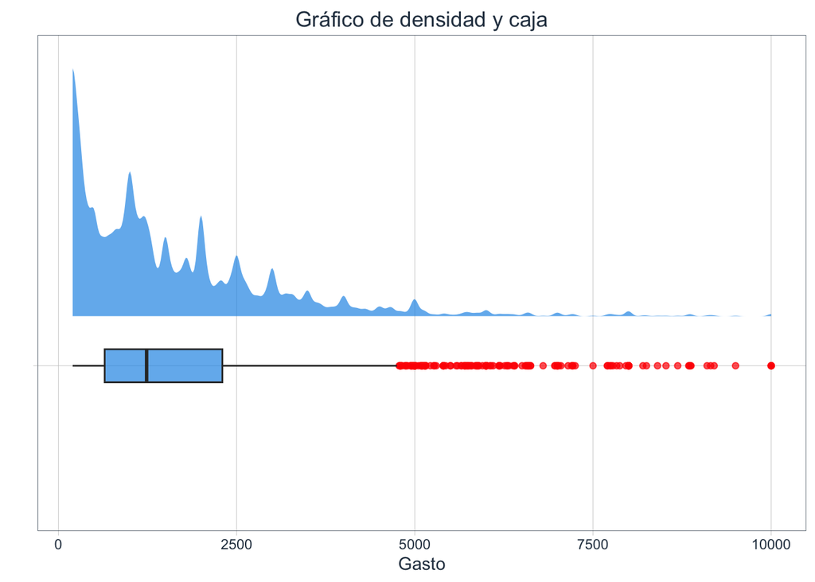

En ese sentido, para obtener estimaciones precisas es necesario utilizar enfoques estadísticos adecuados que permiten considerar la estructura jerárquica presente en el estudio del gasto por estadía generado por los turistas que visitan el país, capturando la variabilidad entre los turistas como individuos y teniendo en cuenta la estructura jerárquica presente según el destino principal que estos visitan. Los modelos multinivel permiten incorporar estructuras jerárquicas en el análisis teniendo en cuenta los efectos fijos como los efectos aleatorios lo cual los hace especialmente útiles para analizar datos longitudinales Lindstrom and Bates (1990), datos de medidas repetidas o agrupados en diferentes niveles.

El Instituto Hondureño de Turismo (2016) en su boletín de estadísticas presenta las tendencias del sector turismo en Honduras durante el periodo `2012`-`2016` el cual es de mucha importancia para este trabajo, donde se usan los datos generados por la encuesta de caracterización del visitante del visitante, `2021` (ECV). Dicha encuesta extrae el gasto por estadía generado por los turistas que ingresan al país, y se realiza al momento que el turista ha realizado una gran parte de su estadía y esta cerca de regresar a su país de residencia.

Este estudio propone un modelo probabilístico `log-normal` multinivel estratificado por la zona visitada por los turistas, con medias entre grupos y varianza desconocidas. El modelo propuesto obtiene estimaciones precisas del gasto turístico en Honduras y las colas pesadas de la distribución log-normal permite tener estimaciones resistente a gastos atípicos. Adicionalmente, la estructura multinivel del modelo permite determinar la variabilidad del gasto en los diferentes destinos turísticos del país como estructura jerárquica, con el fin de proporcionar información más precisa y relevante para la planificación estratégica para impulsar el crecimiento y desarrollo del sector turismo. La inferencia de los parámetros desconocidos se realizo mediante un enfoque Bayesiano con distribuciones a priori débiles y poco informativas Gelman et al. (2020a), y las distribuciones a posteriori del modelo propuesto son muestreadas utilizando un Monte Carlo Hamiltoneano Duane et al. (1987); mediante el algoritmo NUTS Hoffman and Gelman (2014a) realizando las implementaciones en Stan S. D. Team (2017a), mediante el software computacional R. C. Team (2017) . Nuestro modelo fue comparado con otros modelos recientes de la literatura que al ser modelos globales no contemplan la variabilidad entre grupos que presentan los datos. Comparamos la capacidad predictiva de los modelos utilizando validación cruzada Vehtari et al. (2015) y el criterio de información de Watanabe Watanabe (2010), donde nuestro modelo superó a los modelos de la literatura, siendo este el modelo con mejor capacidad predictiva.

## Antecedentes

Los modelos multinivel, también conocidos como modelos de efectos mixtos son ampliamente utilizados para el análisis de datos, estos modelos permiten tener en cuenta los efectos fijos como los efectos aleatorios lo cual los hace especialmente útiles para analizar datos longitudinales Lindstrom and Bates (1990) o de panel Zubizarreta Barrenetxea (2020), Proença and Soukiazis (2005), datos de medidas repetidas o agrupados en diferentes niveles. En las ultimas décadas las metodologías estadísticas para analizar medidas repetidas han tenido un notable desarrollo debido a la facilidad de su implementación gracias a los avances del la computación.

Laird and Ware (1982) introdujo los modelos multinivel y su aplicación en el análisis de datos longitudinales que tiene en cuenta los efectos fijos como los efectos aleatorios, este trabajo sentó bases para el desarrollo de los modelos mixtos en diversas áreas de investigación. Adicionalmente, las estimaciones mediante los modelos multinivel se pueden obtener utilizando diferentes métodos; Correa Morales and Salazar Uribe (2016) aborda cada una de estas y explica en detalle como pueden ser obtenidas a partir de medidas repetidas o longitudinales. Los primeros métodos numéricos para la estimación en los modelos multinivel son mínimos cuadrados Bates and Watts (1988); máxima verosimilitud Lindstrom and Bates (1988); y máxima verosimilitud restringida Lindstrom and Bates (1990) . En la actualidad los métodos Bayesianos se han vuelto popular para estimar modelos con estructuras multinivel ya que permiten obtener estimaciones confiables de los efectos fijos y aleatorios mediante la introducción de información adicional a través de la distribución a priori, y permiten cuantificar la incertidumbre de los efectos mediante el uso de la distribución a posteriori Bürkner (2018) .

Estos modelos son una extensión de los modelos de regresión lineal que acoplan varios modelos lineales para cada nivel de análisis, es decir considerar dentro un mismo modelo los distintos niveles de la estructura jerárquica y conocer la variabilidad debida al segundo nivel Fernández (2012), del mismo modo un modelo Bayesiano multinivel se construye a partir del modelo de regresión lineal ordinario y intentará predecir la variable de respuesta ($y_i$) mediante una combinación lineal de un intercepto y una pendiente que cuantifica la influencia de un predictor ($x_i$) , para mas detalles ver Rivas Martínez and Cruz Torres (2022) . Las siguientes ecuaciones muestran la estructura clásica de un modelo lineal simple,

$$y_i = \alpha+\beta x_i + \sigma_{e}e_i, \quad e_i \sim N(0,1).$$

En este modelo las variables de respuesta $y_i$ se distribuyen normalmente alrededor de la media $\alpha+\beta x_i$ y varianza residual $\sigma_{e}^{2}$. El modelo anterior se puede extender al siguiente modelo multinivel con $j$ niveles o grupos, incorporando un intercepto variable expresado a continuación:

$$y_{ij} =\alpha_{j}+\beta x_i + \sigma_{e}e_i, \quad e_i \sim N(0,1);$$

$$\alpha_{j} \sim N(\alpha,\sigma_{\alpha}^2) \quad \text{para todo } j \in 1,2,\ldots, J.$$

donde $\alpha_{ij}$ indica que a cada grupo $j$ se le da un intercepto único, Rivas Martínez and Cruz Torres (2022) menciona que además de la varianza $\sigma_{e}^{2}$ también se está estimando un componente más $\sigma_{\alpha}^{2}$ que representa la varianza de la distribución de los interceptos variables, esta se considera como la variación del parámetro $\alpha$ entre los grupos $j$, siguiendo una metodología similar es posible introducir un termino de pendiente variables que pueda cambiar según el grupo $j$.

$$\begin{equation}
y_{ij} =\alpha_{j}+\beta_j x_{i,j} + \sigma_{e}e_i, \quad e_i \sim N(0,1);
\end{equation}$$
$$\begin{equation*}
\alpha_{j} \sim N(\alpha,\sigma_{\alpha}^2), \quad \beta_{j} \sim N(\beta,\sigma_{\beta}^2), \quad \text{para todo } j \in 1,2,\ldots, J.
\end{equation*}$$

A estas pendientes variables se les asigna una distribución a priori centrada en la gran pendiente $\beta$, y con varianza $\sigma_{\beta}^2$. Con lo anterior, la inferencia Bayesiana nos permite realizar todas estas aseveraciones posibles que podemos aplicar en los modelos multinivel, para ello supongamos que tenemos $K$ observaciones agrupadas en $J$ grupos, la variable de interés es $y_{ij}$ que representa la observación $i-$ésima en el grupo $j$, podemos modelar la variable $y_{ij}$ en un modelo multinivel lineal Bayesiano de la siguiente manera;

$$\begin{equation}
y_{i,j} =\mu_{j} + \beta_j x_i +\sigma_{e}e_i, \quad e_i \sim N(0,1);
\end{equation}$$
$$\begin{equation*}
\mu_{j} \sim N(\mu,\sigma_{\mu}^2), \ \beta_j \sim N(\beta, \sigma_\beta), \quad \sigma_{e} \sim \text{student-t}(v_e),
\end{equation*}$$

con distribuciones a priori:

$$\begin{equation*}
\mu \sim N(\mu_0,\sigma_{\mu0}^2), \ \beta \sim N(\beta_0,\sigma_{\beta0}^2), \quad \sigma_\mu \sim \text{student-t}(v_0), \ \sigma_\beta \sim \text{student-t}(v_1).
\end{equation*}$$

donde, $y_{ij}$ es la observación i-ésima en el grupo $j$, $\mu_{j}$ es la media del grupo $j$ para la observación $i$ centrada en la media global $\mu$ y escala $\sigma_\mu$; y $\sigma_{e}^{2}$ es la varianza asociada con las observaciones individuales, también conocida como varianza residual o error relativo. Los valores $\mu_0, \beta_0, \sigma_{\mu0}, \sigma_{\beta0}, v_e, v_0$ y $v_1$ son hiper-parámetros conocidos y elegidos por el investigador.

Las actividades turísticas se consideran como una de las fuentes más importantes en el crecimiento económico de un país es por ello que la estimación del gasto turístico es un aspecto fundamental para comprender el impacto y poder tomar decisiones adecuadas. En base a ello se han realizado diversos trabajos a lo largo del tiempo, como Hung, Shang, and Wang (2013) el cual es uno de los primeros trabajos en aplicar un análisis multinivel de los determinantes de gasto turístico de los hogares donde los resultados obtenidos indican que las variables como edad, renta familiar, la propiedad de un vehículo y el uso del internet influyen positivamente en el gasto turístico, Zubizarreta Barrenetxea (2020) propone un modelo de regresión múltiple para una cuantificación del gasto turístico, asimismo Vena Oya (2020) trabajo con determinantes del gasto turístico aplicando varios modelos multinivel.

Uno de los problemas que se generan al momento de realizar estimaciones del gasto turístico es que se obtienen colas pesadas en las distribuciones, esto debido a que hay muchos factores que pueden influir Gómez–Déniz, Dávila-Cárdenes, and Boza-Chirino (2022). A lo largo de estos años muchos estudios se han enfocado en abordar este problema de colas pesadas; Craggs and Schofield (2009) mencionan que una solución es segmentar el gasto turístico por categorías en el cual identificaron asociaciones estadísticamente significativas entre los distintos segmentos de gasto, examinando la importancia de una serie de variables socio-económicas y de comportamiento. Gómez-Déniz, Pérez-Rodríguez, and Boza-Chirino (2020) proponen que otra forma es dividir el gasto total de los turistas basados en el gasto según el país de origen y destino que estos tomen, por otra parte, en estudios más recientes como Nolasco Palomino (2022) utilizaron series temporales para pronosticar el gasto medio de turista en España.

El modelo presentado por Gómez–Déniz, Dávila-Cárdenes, and Boza-Chirino (2022), cumple con todas las características de nuestra investigación dado que sera un punto de comparación con nuestro modelo propuesto, Gómez–Déniz, Dávila-Cárdenes, and Boza-Chirino (2022) prueban en su artículo que realizando una reparametrización de la distribución `log-skew` normal de tres parámetros para la modelización del gasto turístico en base usando distintas covariables como el país de origen, destino y el gasto total, se obtienen resultados satisfactorios en los datos del gasto en las las partes de la distribución empírica, de igual forma el modelo se adapta bien para captar la asimetría, curtosis y colas pesadas que las tres variables mencionadas tienden a presentar en la practica, como lo es en nuestro caso, ver Figure 2. En tal sentido por ello utilizamos modelos multinivel y así poder obtener estimaciones precisas en la variabilidad del gasto turístico.

## Modelización del gasto turístico por estadía en Honduras

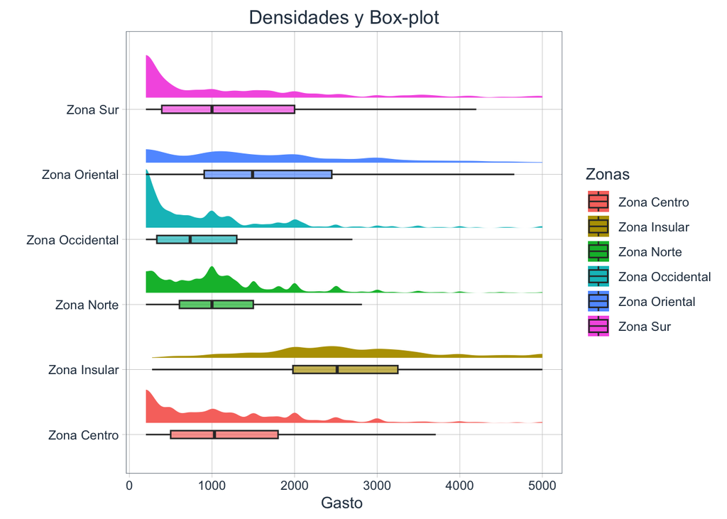

Figure 2: Distribución del gasto turístico por estadía desagregado por zonas que visitaron en Honduras, según los datos recolectados por la encuesta (ECV).

El cuadro Table 1 proporciona un resumen detallado del gasto turístico de los visitantes sin aplicarle la transformación logarítmica a los datos, desglosado por las diferentes zonas que visitaron en Honduras, cada una de ella exhibe características únicas en términos de patrones de gasto, mencionar que las zonas están divididas según la (ECV) de la siguiente manera; *`Zona centro, insular, norte, occidental, oriental y sur`*. Por ejemplo, la *`zona centro`* muestra una concentración moderada del gasto al rededor de la mediana indicando una distribución relativamente equilibrada, caso contrario en la `zona insular` donde se observa una mediana más alta de $2{,}635$, sugiriendo una concentración de gastos excepcionalmente altos y de valores atípicos. Además, las *`zonas norte, oriental`* y *`sur`* muestran una asimetría notable indicando una distribución desplazada ó colas pesadas hacia valores superiores.

Table 1: Resumen de gasto turístico desagregado por zonas, de los visitantes que ingresaron al país año 2021

| Zona | n | min. | Q1 | mediana | Q3 | max. | asimetría | kurtósis |
| --- | --- | --- | --- | --- | --- | --- | --- | --- |
| Centro | 1,173 | 14.62 | 327.69 | 934.58 | 1,720.00 | 15,000.00 | 3.46 | 24.18 |
| Insular | 805 | 60.00 | 2,000.00 | 2,635.00 | 3,500.00 | 20,000.00 | 3.52 | 24.35 |
| Norte | 1,338 | 6.98 | 459.06 | 1,000.00 | 1,500.00 | 22,653.31 | 6.24 | 61.67 |
| Occidental | 616 | 7.76 | 134.64 | 332.93 | 1,000.00 | 10,000.00 | 3.54 | 21.94 |
| Oriental | 342 | 28.93 | 295.33 | 1,192.18 | 2,137.50 | 10,500.00 | 1.84 | 8.44 |
| Sur | 437 | 5.00 | 200.00 | 535.52 | 1,739.43 | 10,184.09 | 2.32 | 9.60 |
| Global | 4,711 | 5.00 | 350.00 | 1,050.00 | 2,050.00 | 22,653.00 | 3.58 | 27.27 |

En la Figure 2, se presenta las densidades del gasto turístico desagregado por zonas, donde se observa que la mayor parte de la información del gasto se concentra entre los primeros tres mil valores, el gráfico de cajas revela muy poca información, más del $87\%$ de los datos están cercanos a cero, estos gráficos indican que el gasto turístico no sigue una distribución normal. En ese sentido, se propone aplicar una transformación logarítmica a los datos para lidiar con los valores extremos de la muestra, el cual representan aproximadamente el $5\%$, ver Figure 1. En la Figure 3, se presentan la transformación logarítmica del gasto desagregado por zonas, donde las densidades indican que los datos siguen una distribución normal, el gráfico de cuantiles mejora significativamente al aplicar dicha transformación en comparación con la Figure 2 .

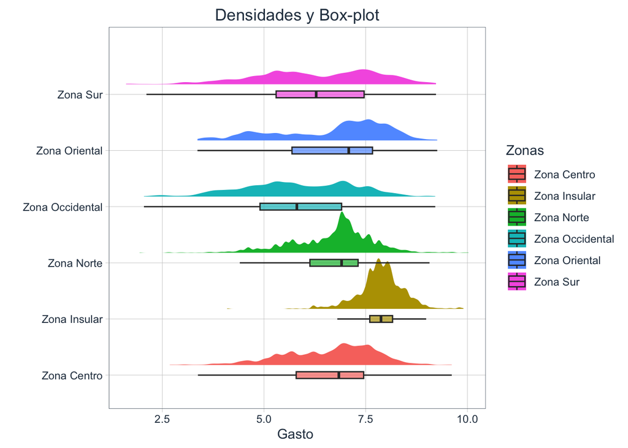

Figure 3: Distribución del gasto turístico logarítmico por estadía desagregado por zonas que visitaron en Honduras, según los datos recolectados por la encuesta (ECV).

$$\begin{equation}
\log(y_{ij}) \sim N(\mu_j,\sigma),
\end{equation}$$

con distribuciones a priori:

- $\mu_j \sim N(0,10)$ es la media entre grupos del gasto turístico para la zona j; que siguen una distribución normal con media cero y varianza diez.
- $\sigma \sim$ student-t$(5,0,10)$ es la varianza global del logaritmo del gasto, que sigue un distribución *`t de student`* definida en los valores positivos, con $v = 5$ grados de libertad, centrada en cero y con escala de diez.

En este estudio utilizamos distribuciones a priori débilmente informativas, y se eligen de tal forma que dichas distribuciones provean poca información y mejoren la geometría de la función propuesta tal que el muestreo de la distribución a posteriori sea mas estable, para mas detalles ver Gelman et al. (2020b) . Asimismo, realizaremos una comparación con la distribución propuesta por Gómez–Déniz, Dávila-Cárdenes, and Boza-Chirino (2022) , el cual utilizó un modelo *`log-normal asimétrico`* para estimar el gasto turístico global. El modelo viene dado de la siguiente manera:

$$\begin{equation}
\log(y_{i}) \sim \text{skew-N}(\mu,\sigma, \alpha),
\end{equation}$$

con parámetros de locación ($\mu$), escala ($\sigma$) y de forma ($\alpha$) desconocidos, y distribuciones a priori:

- $\mu \sim N(0,10)$ es la media del gasto turístico global; que siguen una distribución normal con media cero y varianza diez.
- $\sigma \sim$ student-t$(3,0,10)$ es la varianza global del logaritmo del gasto, que sigue un distribución *`t de student`* definida en los valores positivos, con $v = 3$ grados de libertad, centrada en cero y con escala de diez.
- $\alpha \sim N(0,1)$ es la asimetría global del logaritmo del gasto, que sigue un distribución *`normal`* estándar.

Donde $i=1,\dots,n$ son los índices de los datos globales, $n$ denota el número de observaciones, skew-N() denota la densidad de una distribución normal asimétrica, y las distribuciones a priori elegidas son débilmente informativas.

Para realizar las estimaciones del gasto turístico de los modelos propuestos, utilizaremos métodos de Markov Chain Monte Carlo (MCMC) como Metropolis et al. (1953), Hastings (1970). En particular emplearemos un Monte Carlo Hamiltoneano Duane et al. (1987), Hoffman and Gelman (2014b) implementado en el lenguaje de programación probabilista Stan, Development. Team (2017) , y ejecutado en el lenguaje de programación R Stan, Development. Team (2017), Bürkner (2017). Para cada implementación se corrieron cuatro cadenas con valores iniciales distintas, con un total de $2,000$ iteraciones por cadena, eliminando las primeras $1,000$ iteraciones por cadena (*`warm-up`*). Presentamos las distribuciones a posteriori del modelo multinivel propuesto y evaluamos la convergencia de las cadenas utilizando el factor de convergencia ($\hat{R}$), y los tamaños de muestra efectivos ($ess$) Vehtari et al. (2020). Para las visualizaciones de las cadenas se usó trazas y gráficos de densidades Gabry et al. (2019), Gabry and Mahr (2019) . Para, evaluar el ajuste del modelo utilizaremos evaluación de la densidad predictiva (*`posterior predictive checks`*) visualizando el ajuste con gráficos de densidades, Säilynoja, Bürkner, and Vehtari (2021). Finalmente, comparamos ambos modelos utilizando validación cruzada, ver Vehtari, Gelman, and Gabry (2016) . Dicho método computa las esperanzas de las log-predictivas ($elpd$) removiendo una observación $y_{i}$ de la muestra y computar la log-predictiva del modelo para dicha observación faltante; este procedimiento es caro computacionalmente pero puede ser aproximado usando un muestreo por importancia con un suavizado de Pareto Vehtari et al. (2015) , o por submuestreo Magnusson et al. (2020).

## Análisis y Resultados

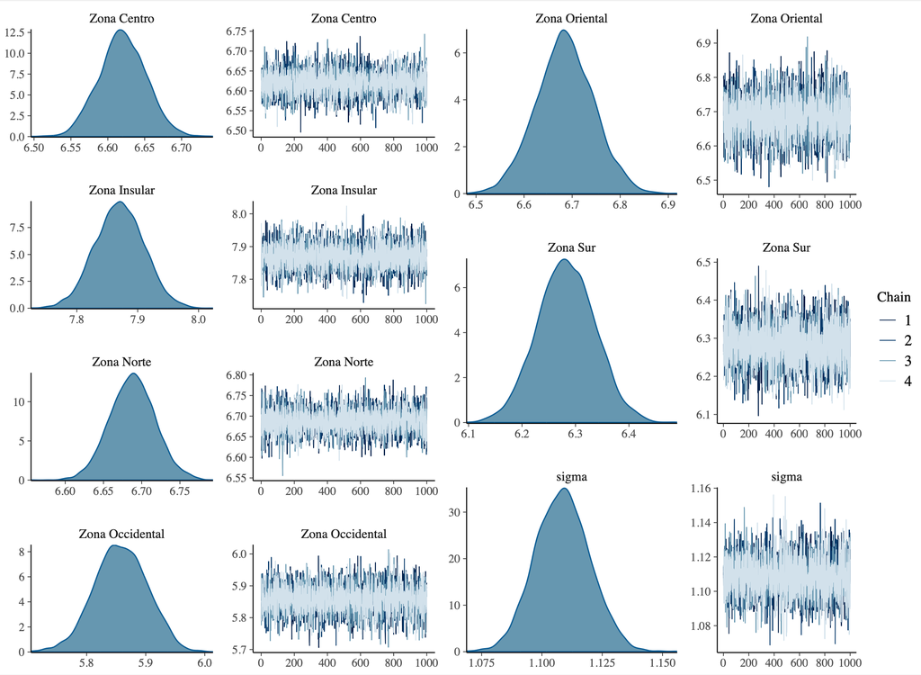

Figura 4: Densidades y cadenas de Markov del modelo log normal multinivel propuesto.

Table 2: Resumen de las distribuciones a posteriori obtenidas del modelo log normal multinivel

| variable | media | mediana | sd | MAD | Q5 | Q95 | Rhat | ess_bulk | ess_tail |
| --- | --- | --- | --- | --- | --- | --- | --- | --- | --- |
| Zona Centro | 6.62 | 6.62 | 0.03 | 0.03 | 6.57 | 6.67 | 1 | 5,429.56 | 2,758.98 |
| Zona Insular | 7.87 | 7.87 | 0.04 | 0.04 | 7.80 | 7.94 | 1 | 6,382.14 | 3,077.30 |
| Zona Norte | 6.69 | 6.69 | 0.03 | 0.03 | 6.64 | 6.74 | 1 | 5,623.11 | 2,849.54 |
| Zona Occidental | 5.86 | 5.86 | 0.04 | 0.05 | 5.78 | 5.93 | 1 | 5,469.62 | 3,097.26 |
| Zona Oriental | 6.69 | 6.68 | 0.06 | 0.06 | 6.59 | 6.78 | 1 | 5,847.90 | 2,773.99 |
| Zona Sur | 6.28 | 6.28 | 0.05 | 0.05 | 6.19 | 6.37 | 1 | 6,406.71 | 2,982.07 |
| sigma | 1.11 | 1.11 | 0.01 | 0.01 | 1.09 | 1.13 | 1 | 5,716.40 | 3,060.18 |

Los valores *`ess_bulk`* y *`ess_tail`*, son indicadores para medir la eficiencia de las estimaciones de tamaño de muestra efectivo, la primera se enfoca en la regiones donde la densidad de probabilidad es más alta es decir la parte central de la distribución y la segunda en las colas o extremos de la distribución, estos valores deben ser cercanos a $4000$ o similares entre si, en nuestro caso los resultados indican que en cada zona refleja la eficiencia con lo que las cadenas de están explorando y muestreando en ambas partes de la distribución. Finalmente, los valores obtenidos se observan bien y los indicadores de convergencia muestrean bien nuestro modelo propuesto para la estimación del gasto turístico el cual se puede observar en la figura *4*, donde las cadenas MCMC lograron hacer un *`"mixing"`* efectivo al juntarse entre sí y parecer estacionaras, las densidades se ven simétricas y sin múltiples modas, siendo estos indicadores de convergencia.

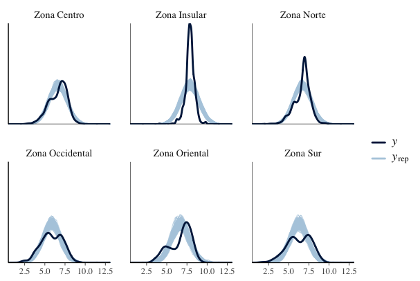

Figura 5: Posterior Predictive Checks del modelo log normal multinivel propuesto.

Table 3: Resumen de la comparación del modelo log normal multinivel y Gómez et al. (2022)

| modelo | elpd_diff | se_diff | elpd_loo | waic |
| --- | --- | --- | --- | --- |
| multi-nivel | 0.00 | 0.00 | -7,172.74 | 14,345.47 |
| Gomez | -577.05 | 28.35 | -7,749.78 | 15,499.56 |

## Conclusiones

En la comparación entre el modelo *`log normal`* multi-nivel propuesto y el modelo de referencia presentado por Gómez–Déniz, Dávila-Cárdenes, and Boza-Chirino (2022) se observa una serie de diferencias sustanciales que respaldan la viabilidad y ventajas de nuestro enfoque. Una característica destacada del modelo propuesto es la eliminación de la necesidad de estimar un parámetro de forma, el cual suele ser bien engorroso de estimar, esto simplifica el proceso de estimación y refuerza la robustez de las predicciones; en cambio el modelo de Gómez–Déniz, Dávila-Cárdenes, and Boza-Chirino (2022) asume una uniformidad del gasto en todo el país sin considerar las variaciones que se presenten en las distintas zonas turísticas es decir para los datos del gasto turístico global como se observa en la Figure 1 . Nuestro modelo multinivel si aborda explícitamente estas diferencias que surgen con lo cual se obtienen estimaciones más precisas y ajustadas como se observó en los resultados de la validación cruzada. Asimismo, es importante resaltar que según el criterio *`LOO(Leave-One-Out)`* obtenido nuestro modelo puede predecir una nueva información con precisión.

En este trabajo, hemos profundizado la relevancia que tienen las distribuciones *`log normales`* y los modelos multinivel. Las distribuciones *`log normales`* son especialmente útiles para modelar datos en los cuales se cuenta con colas pesadas como se observó en la Figure 2 del gasto turístico, permitiendo capturar de manera efectiva los valores atípicos o extremos y al aplicar transformaciones logarítmicas se logró regularizar las distribuciones mejorando la estabilidad y precisión de las estimaciones. En relación a los modelos multinivel hemos podido estudiar la capacidad que estos tienen para identificar la variabilidad y estructura jerárquica de los datos, proporcionando una comprensión enriquecedora y contextualizada de los factores que pueden influir en diversas situaciones de estudio.

## References

Bates, Douglas M, and Donald G Watts. 1988. *Nonlinear Regression Analysis and Its Applications*. Wiley.

Bürkner, Paul-Christian. 2017. “Brms: An R Package for Bayesian Multilevel Models Using Stan.” *Journal of Statistical Software* 80 (1): 1–28. https://doi.org/10.18637/jss.v080.i01.

———. 2018. “Advanced Bayesian Multilevel Modeling with the R Package brms.” *The R Journal* 10 (1): 395–411. https://doi.org/10.32614/RJ-2018-017.

Correa Morales, Juan Carlos, and Juan Carlos Salazar Uribe. 2016. “Introducción a Los Modelos Mixtos.” *Escuela de Estadistica*.

Craggs, Ruth, and Peter Schofield. 2009. “Expenditure-Based Segmentation and Visitor Profiling at the Quays in Salford, UK.” *Tourism Economics* 15 (1): 243–60. https://doi.org/10.5367/000000009787536753.

Duane, Simon, A. D. Kennedy, Brian J. Pendleton, and Duncan Roweth. 1987. “Hybrid Monte Carlo.” *Physics Letters B* 195 (2): 216–22. https://www.sciencedirect.com/science/article/pii/037026938791197X.

Fernández, Virginia Pérez. 2012. “Los Modelos Multinivel En El análisis de Factores de Riesgo de Sibilancias Recurrentes En Lactantes: Enfoques Frecuentista y Bayesiano.” PhD thesis, Universidad de Murcia.

Gabry, Jonah, and Tristan Mahr. 2019. “Bayesplot: Plotting for Bayesian Models.” https://mc-stan.org/bayesplot.

Gabry, Jonah, Daniel Simpson, Aki Vehtari, Michael Betancourt, and Andrew Gelman. 2019. “Visualization in Bayesian Workflow.” *J. R. Stat. Soc. A* 182: 389–402. https://doi.org/10.1111/rssa.12378.

Gelman, Andrew, Aki Vehtari, Daniel Simpson, Charles C. Margossian, Bob Carpenter, Yuling Yao, Lauren Kennedy, Jonah Gabry, Paul-Christian Bürkner, and Martin Modrák. 2020a. “Bayesian Workflow.” https://arxiv.org/abs/2011.01808.

Gelman, Andrew, Aki Vehtari, Daniel Simpson, Charles C Margossian, Bob Carpenter, Yuling Yao, Lauren Kennedy, Jonah Gabry, Paul-Christian Bürkner, and Martin Modrák. 2020b. “Bayesian Workflow.” *arXiv Preprint arXiv:2011.01808*.

Gómez-Déniz, Emilio, Jorge V Pérez-Rodríguez, and José Boza-Chirino. 2020. “Modelling Tourist Expenditure at Origin and Destination.” *Tourism Economics* 26 (3): 437–60. https://doi.org/10.1177/1354816619840845.

Gómez–Déniz, E., N. Dávila-Cárdenes, and J. Boza-Chirino. 2022. “Modelling Expenditure in Tourism Using the Log-Skew Normal Distribution.” *Current Issues in Tourism* 25 (14): 2357–76. https://doi.org/10.1080/13683500.2021.1960282.

Hastings, W. K. 1970. “Monte Carlo Sampling Methods Using Markov Chains and Their Applications.” *Biometrika* 57 (1): 97–109. http://www.jstor.org/stable/2334940.

Hoffman, Matthew D., and Andrew Gelman. 2014a. “The No-u-Turn Sampler: Adaptively Setting Path Lengths in Hamiltonian Monte Carlo.” *Journal of Machine Learning Research* 15 (47): 1593–623. http://jmlr.org/papers/v15/hoffman14a.html.

———. 2014b. “The No-u-Turn Sampler: Adaptively Setting Path Lengths in Hamiltonian Monte Carlo.” *Journal of Machine Learning Research* 15: 1593–623. http://jmlr.org/papers/v15/hoffman14a.html.

Hung, Wei-Ting, Jui-Kuo Shang, and Fei-Ching Wang. 2013. “A Multilevel Analysis on the Determinants of Household Tourism Expenditure.” *Current Issues in Tourism* 16 (6): 612–17. https://doi.org/10.1080/13683500.2012.725714.

Instituto Hondureño de Turismo, República de Honduras. 2016. “Boletín de Estadísticas de Turismo 2012 - 2016.” https://iht.hn/es/boletin-2012-2016.

Laird, Nan M., and James H. Ware. 1982. “Random-Effects Models for Longitudinal Data.” *Biometrics* 38 (4): 963–74. http://www.jstor.org/stable/2529876.

Lindstrom, Mary J., and Douglas M. Bates. 1988. “Newton-Raphson and EM Algorithms for Linear Mixed-Effects Models for Repeated-Measures Data.” *Journal of the American Statistical Association* 83 (404): 1014–22. http://www.jstor.org/stable/2290128.

———. 1990. “Nonlinear Mixed Effects Models for Repeated Measures Data.” *Biometrics* 46 (3): 673–87. http://www.jstor.org/stable/2532087.

Magnusson, Måns, Michael Riis Andersen, Johan Jonasson, and Aki Vehtari. 2020. “Leave-One-Out Cross-Validation for Bayesian Model Comparison in Large Data.” https://arxiv.org/abs/2001.00980.

Metropolis, Nicholas, Arianna W. Rosenbluth, Marshall N. Rosenbluth, Augusta H. Teller, and Edward Teller. 1953. “Equation of State Calculations by Fast Computing Machines.” *The Journal of Chemical Physics* 21 (6): 1087–92. https://doi.org/10.1063/1.1699114.

Nolasco Palomino, Evelyn Yanela. 2022. “Pronóstico Del Gasto Medio Por Turista En España Mediante El Uso de Series Temporales.”

Proença, Sara A, and Elias Soukiazis. 2005. “Demand for Tourism in Portugal: A Panel Data Approach.”

Rivas Martínez, Lesky Ibeth, and Cristian Andrés Cruz Torres. 2022. “Análisis Multinivel de Factores Que Afectan El Rendimiento Escolar En Español Tercer Grado En Honduras.” *Paradigma: Revista de Investigación Educativa* 29 (48): 93–119. https://iniees.vrip.upnfm.edu.hn/ojs/index.php/Paradigma/article/view/171.

Säilynoja, Teemu, Paul-Christian Bürkner, and Aki Vehtari. 2021. “Graphical Test for Discrete Uniformity and Its Applications in Goodness of Fit Evaluation and Multiple Sample Comparison.” *arXiv Preprint arXiv:2103.10522*.

Stan, Development. Team. 2017. “Stan: A c++ Library for Probability and Sampling, Version 2.16.0.” http://mc-stan.org/.

Team, R Core. 2017. *R: A Language and Environment for Statistical Computing*. Vienna, Austria: R Foundation for Statistical Computing. https://www.R-project.org/.

Team, Stan Development. 2017a. “Stan: A c++ Library for Probability and Sampling, Version 2.14. 0.” http://mc-stan.org/.

Vehtari, Aki, Andrew Gelman, and Jonah Gabry. 2016. “Practical Bayesian Model Evaluation Using Leave-One-Out Cross-Validation and WAIC.” *Statistics and Computing* 27 (5): 1413–32. https://doi.org/10.1007/s11222-016-9696-4.

Vehtari, Aki, Andrew Gelman, Daniel Simpson, Bob Carpenter, and Paul-Christian Bürkner. 2020. “Rank-Normalization, Folding, and Localization: An Improved $\widehat{R}$ for Assessing Convergence of MCMC.” *Bayesian Analysis*. International Society for Bayesian Analysis. https://doi.org/10.1214/20-BA1221.

Vehtari, Aki, Daniel Simpson, Andrew Gelman, Yuling Yao, and Jonah Gabry. 2015. “Pareto Smoothed Importance Sampling.” https://arxiv.org/abs/1507.02646.

Vena Oya, Julio. 2020. “Determinantes Del Gasto Efectivo En El Turismo Cultural.” http://hdl.handle.net/10481/62288.

Watanabe, Sumio. 2010. “Asymptotic Equivalence of Bayes Cross Validation and Widely Applicable Information Criterion in Singular Learning Theory.” *Journal of Machine Learning Research* 11. http://www.jmlr.org/papers/volume11/watanabe10a/watanabe10a.pdf.

Zubizarreta Barrenetxea, Leire. 2020. “Análisis Estadı́stico Del Gasto Medio Del Turista En España y Los Factores Que Lo Determinan: Una Propuesta de análisis de Datos de Panel.”